# 4 Clustering and classification

## Task 2: The data

**Load the Boston data from the MASS package. Explore the structure and the dimensions of the data and describe the dataset briefly, assuming the reader has no previous knowledge of it.**

```r
library(MASS); library(tidyverse); library(psych); library(knitr);
library(kableExtra); library(ggplot2); library(corrplot); library(ggpubr)
library(GGally); library(caret)
```

```r
data("Boston")
```

The *Boston* dataset (Harrison & Rubinfield , 1978; Belsey, Kuh, & Welsch, 1980) from the *MASS* package is about the housing values in suburbs of Boston. Information about the dataset can be found [here](https://stat.ethz.ch/R-manual/R-devel/library/MASS/html/Boston.html). The dataset contains following variables:

**Table 1** Variables in the dataset

| Variables | Information |
| --- | --- |
| crim | per capita crime rate by town. |
| zn | proportion of residential land zoned for lots over 25,000 sq.ft. |
| indus | proportion of non-retail business acres per town. |
| chas | Charles River dummy variable (= 1 if tract bounds river; 0 otherwise). |
| nox | nitrogen oxides concentration (parts per 10 million). |
| rm | average number of rooms per dwelling. |
| age | proportion of owner-occupied units built prior to 1940. |
| dis | weighted mean of distances to five Boston employment centres. |
| rad | index of accessibility to radial highways. |
| tax | full-value property-tax rate per $10,000. |
| ptratio | pupil-teacher ratio by town. |
| black | 1000(Bk - 0.63)2 where Bk is the proportion of blacks by town. |
| lstat | lower status of the population (percent). |
| medv | median value of owner-occupied homes in $1,000s. |

```
## Observations: 506
## Variables: 14
## $ crim    <dbl> 0.00632, 0.02731, 0.02729, 0.03237, 0.06905, 0.02985, ...
## $ zn      <dbl> 18.0, 0.0, 0.0, 0.0, 0.0, 0.0, 12.5, 12.5, 12.5, 12.5,...
## $ indus   <dbl> 2.31, 7.07, 7.07, 2.18, 2.18, 2.18, 7.87, 7.87, 7.87, ...
## $ chas    <int> 0, 0, 0, 0, 0, 0, 0, 0, 0, 0, 0, 0, 0, 0, 0, 0, 0, 0, ...
## $ nox     <dbl> 0.538, 0.469, 0.469, 0.458, 0.458, 0.458, 0.524, 0.524...
## $ rm      <dbl> 6.575, 6.421, 7.185, 6.998, 7.147, 6.430, 6.012, 6.172...
## $ age     <dbl> 65.2, 78.9, 61.1, 45.8, 54.2, 58.7, 66.6, 96.1, 100.0,...
## $ dis     <dbl> 4.0900, 4.9671, 4.9671, 6.0622, 6.0622, 6.0622, 5.5605...
## $ rad     <int> 1, 2, 2, 3, 3, 3, 5, 5, 5, 5, 5, 5, 5, 4, 4, 4, 4, 4, ...
## $ tax     <dbl> 296, 242, 242, 222, 222, 222, 311, 311, 311, 311, 311,...
## $ ptratio <dbl> 15.3, 17.8, 17.8, 18.7, 18.7, 18.7, 15.2, 15.2, 15.2, ...
## $ black   <dbl> 396.90, 396.90, 392.83, 394.63, 396.90, 394.12, 395.60...
## $ lstat   <dbl> 4.98, 9.14, 4.03, 2.94, 5.33, 5.21, 12.43, 19.15, 29.9...
## $ medv    <dbl> 24.0, 21.6, 34.7, 33.4, 36.2, 28.7, 22.9, 27.1, 16.5, ...
```

The dataset has 506 observations and 14 variables.

**Original source:**

Harrison, D. and Rubinfeld, D.L. (1978) Hedonic prices and the demand for clean air. *J. Environ. Economics and Management* 5, 81–102. Belsley D.A., Kuh, E. and Welsch, R.E. (1980) *Regression Diagnostics. Identifying Influential Data and Sources of Collinearity.* New York: Wiley.

## Task 3: Exploring the data

**Show a graphical overview of the data and show summaries of the variables in the data. Describe and interpret the outputs, commenting on the distributions of the variables and the relationships between them.**

```r
# exploring descripotive statistics
describe(Boston) %>% kable(caption = "<b>Table 2</b> Descriptive statistics", digits = 2) %>%
  kable_styling(bootstrap_options = "striped", "hover")
```

**Table 2** Descriptive statistics

|  | vars | n | mean | sd | median | trimmed | mad | min | max | range | skew | kurtosis | se |
| --- | --- | --- | --- | --- | --- | --- | --- | --- | --- | --- | --- | --- | --- |
| crim | 1 | 506 | 3.61 | 8.60 | 0.26 | 1.68 | 0.33 | 0.01 | 88.98 | 88.97 | 5.19 | 36.60 | 0.38 |
| zn | 2 | 506 | 11.36 | 23.32 | 0.00 | 5.08 | 0.00 | 0.00 | 100.00 | 100.00 | 2.21 | 3.95 | 1.04 |
| indus | 3 | 506 | 11.14 | 6.86 | 9.69 | 10.93 | 9.37 | 0.46 | 27.74 | 27.28 | 0.29 | -1.24 | 0.30 |
| chas | 4 | 506 | 0.07 | 0.25 | 0.00 | 0.00 | 0.00 | 0.00 | 1.00 | 1.00 | 3.39 | 9.48 | 0.01 |
| nox | 5 | 506 | 0.55 | 0.12 | 0.54 | 0.55 | 0.13 | 0.38 | 0.87 | 0.49 | 0.72 | -0.09 | 0.01 |
| rm | 6 | 506 | 6.28 | 0.70 | 6.21 | 6.25 | 0.51 | 3.56 | 8.78 | 5.22 | 0.40 | 1.84 | 0.03 |
| age | 7 | 506 | 68.57 | 28.15 | 77.50 | 71.20 | 28.98 | 2.90 | 100.00 | 97.10 | -0.60 | -0.98 | 1.25 |
| dis | 8 | 506 | 3.80 | 2.11 | 3.21 | 3.54 | 1.91 | 1.13 | 12.13 | 11.00 | 1.01 | 0.46 | 0.09 |
| rad | 9 | 506 | 9.55 | 8.71 | 5.00 | 8.73 | 2.97 | 1.00 | 24.00 | 23.00 | 1.00 | -0.88 | 0.39 |
| tax | 10 | 506 | 408.24 | 168.54 | 330.00 | 400.04 | 108.23 | 187.00 | 711.00 | 524.00 | 0.67 | -1.15 | 7.49 |
| ptratio | 11 | 506 | 18.46 | 2.16 | 19.05 | 18.66 | 1.70 | 12.60 | 22.00 | 9.40 | -0.80 | -0.30 | 0.10 |
| black | 12 | 506 | 356.67 | 91.29 | 391.44 | 383.17 | 8.09 | 0.32 | 396.90 | 396.58 | -2.87 | 7.10 | 4.06 |
| lstat | 13 | 506 | 12.65 | 7.14 | 11.36 | 11.90 | 7.11 | 1.73 | 37.97 | 36.24 | 0.90 | 0.46 | 0.32 |
| medv | 14 | 506 | 22.53 | 9.20 | 21.20 | 21.56 | 5.93 | 5.00 | 50.00 | 45.00 | 1.10 | 1.45 | 0.41 |

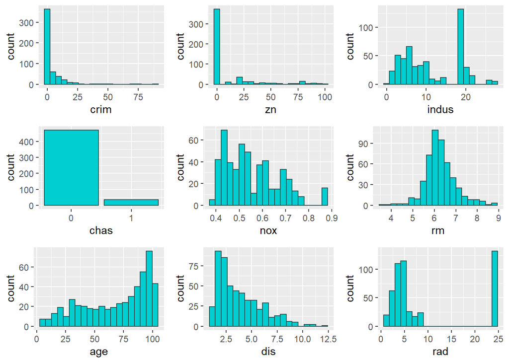

```r
# visualizing distributions
plots <- list(names(Boston[,-4]))
for(i in names(Boston[,-4])) {
    plots[[i]] <- ggplot(data=Boston) + geom_histogram(aes_string(x=i),
                                                       color="darkslategray", fill="darkturquoise",
                                                       bins = 20)
}

plots$chas <- ggplot(Boston, aes(chas)) + geom_bar(color="darkslategray", fill="darkturquoise") +
  scale_x_continuous(breaks = 0:1)

fig1 <- ggarrange(plots$crim, plots$zn, plots$indus,
                  plots$chas, plots$nox, plots$rm,
                  plots$age, plots$dis, plots$rad,
                  ncol = 3, nrow = 3)
fig2 <- ggarrange(plots$tax, plots$ptratio, plots$black,
                  plots$lstat, plots$medv,
                  ncol = 3, nrow = 3)

fig1
```

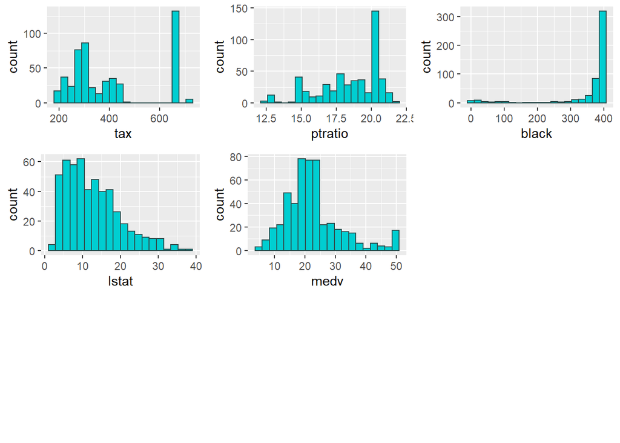

```r
fig2
```

Variables *crim* and *zn*, are considerably positively skewed with a strong floor effect, whereas *black* is negatively skewed with a strong ceiling effect. Variables *indus*, *rad*, and *tax* seem to be are bimodal or have gaps in the histogram followed by high value peaks.

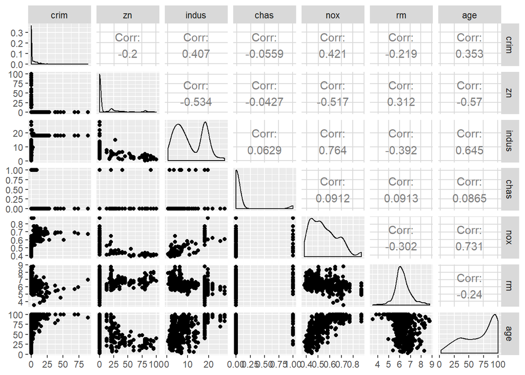

```r
# pairs
ggpairs(Boston[1:7], lower = list(combo = wrap("facethist", bins = 20)))
```

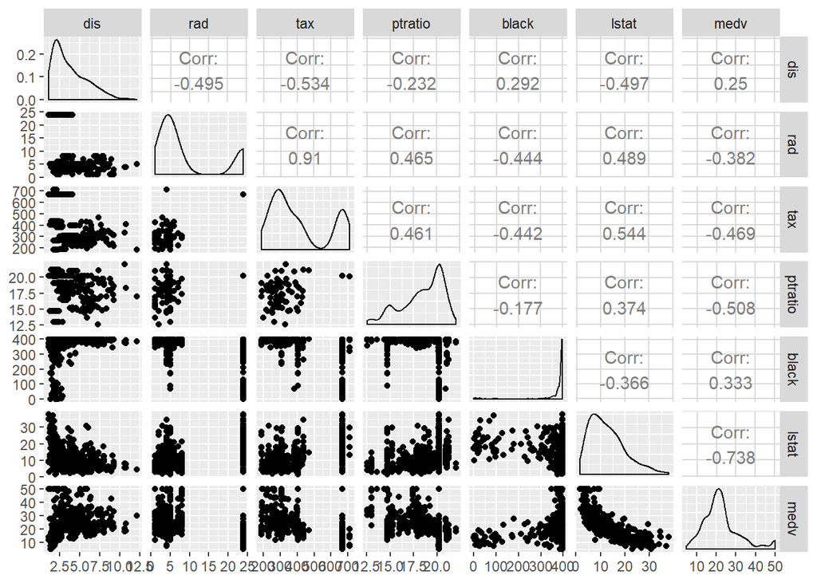

```r
ggpairs(Boston[8:14], lower = list(combo = wrap("facethist", bins = 20)))
```

```r
# correlation matrix
cor.mat <- cor(Boston)

cor.mat %>% kable(digits = 2, caption = "<b>Table 3</b> Correlations") %>%
  kable_styling(bootstrap_options = "striped", "hover")
```

**Table 3** Correlations

|  | crim | zn | indus | chas | nox | rm | age | dis | rad | tax | ptratio | black | lstat | medv |
| --- | --- | --- | --- | --- | --- | --- | --- | --- | --- | --- | --- | --- | --- | --- |
| crim | 1.00 | -0.20 | 0.41 | -0.06 | 0.42 | -0.22 | 0.35 | -0.38 | 0.63 | 0.58 | 0.29 | -0.39 | 0.46 | -0.39 |
| zn | -0.20 | 1.00 | -0.53 | -0.04 | -0.52 | 0.31 | -0.57 | 0.66 | -0.31 | -0.31 | -0.39 | 0.18 | -0.41 | 0.36 |
| indus | 0.41 | -0.53 | 1.00 | 0.06 | 0.76 | -0.39 | 0.64 | -0.71 | 0.60 | 0.72 | 0.38 | -0.36 | 0.60 | -0.48 |
| chas | -0.06 | -0.04 | 0.06 | 1.00 | 0.09 | 0.09 | 0.09 | -0.10 | -0.01 | -0.04 | -0.12 | 0.05 | -0.05 | 0.18 |
| nox | 0.42 | -0.52 | 0.76 | 0.09 | 1.00 | -0.30 | 0.73 | -0.77 | 0.61 | 0.67 | 0.19 | -0.38 | 0.59 | -0.43 |
| rm | -0.22 | 0.31 | -0.39 | 0.09 | -0.30 | 1.00 | -0.24 | 0.21 | -0.21 | -0.29 | -0.36 | 0.13 | -0.61 | 0.70 |
| age | 0.35 | -0.57 | 0.64 | 0.09 | 0.73 | -0.24 | 1.00 | -0.75 | 0.46 | 0.51 | 0.26 | -0.27 | 0.60 | -0.38 |
| dis | -0.38 | 0.66 | -0.71 | -0.10 | -0.77 | 0.21 | -0.75 | 1.00 | -0.49 | -0.53 | -0.23 | 0.29 | -0.50 | 0.25 |
| rad | 0.63 | -0.31 | 0.60 | -0.01 | 0.61 | -0.21 | 0.46 | -0.49 | 1.00 | 0.91 | 0.46 | -0.44 | 0.49 | -0.38 |
| tax | 0.58 | -0.31 | 0.72 | -0.04 | 0.67 | -0.29 | 0.51 | -0.53 | 0.91 | 1.00 | 0.46 | -0.44 | 0.54 | -0.47 |
| ptratio | 0.29 | -0.39 | 0.38 | -0.12 | 0.19 | -0.36 | 0.26 | -0.23 | 0.46 | 0.46 | 1.00 | -0.18 | 0.37 | -0.51 |
| black | -0.39 | 0.18 | -0.36 | 0.05 | -0.38 | 0.13 | -0.27 | 0.29 | -0.44 | -0.44 | -0.18 | 1.00 | -0.37 | 0.33 |
| lstat | 0.46 | -0.41 | 0.60 | -0.05 | 0.59 | -0.61 | 0.60 | -0.50 | 0.49 | 0.54 | 0.37 | -0.37 | 1.00 | -0.74 |
| medv | -0.39 | 0.36 | -0.48 | 0.18 | -0.43 | 0.70 | -0.38 | 0.25 | -0.38 | -0.47 | -0.51 | 0.33 | -0.74 | 1.00 |

**Correlogram showing correlations with p < .05**

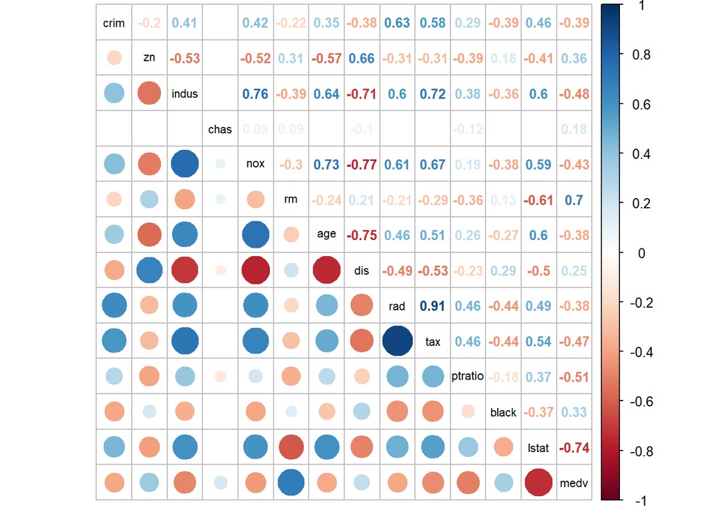

```r
# p-value matrix
cor.mtest <- function(cor.mat, ...) {
    mat <- as.matrix(cor.mat)
    n <- ncol(cor.mat)
    p.mat<- matrix(NA, n, n)
    diag(p.mat) <- 0
    for (i in 1:(n - 1)) {
        for (j in (i + 1):n) {
            tmp <- cor.test(mat[, i], mat[, j], ...)
            p.mat[i, j] <- p.mat[j, i] <- tmp$p.value
        }
    }
  colnames(p.mat) <- rownames(p.mat) <- colnames(mat)
  p.mat
}

p.mat <- cor.mtest(Boston)

# correlogram
corrplot.mixed(cor.mat, lower = "circle", upper = "number", tl.col = "black",
               tl.cex = 0.7, number.cex = 0.8, number.digits = 2,
               p.mat = p.mat, sig.level = 0.05, insig = "blank")
```

The correlation matrix shows that:

The crime rate of the suburb correlates moderately with accessibility to radial highways (r = .63) and property tax rate (r = .58).

Crime is also correlated with low-to-moderate positive associations (.30 < r < .50) with

- *indus* (proportion of non-retail business)
- *nox* (nitrogen oxides concentration)
- *age* (proportion of owner-occupied units built prior to 1940)
- *lstat* (lower status of the population)

…and low-to-moderate negative associations (-.30 > r > -.50) with

- *dis* (distances to employment centres)
- *black* (the proportion of blacks by town)
- *medv* (median value of owner-occupied homes)

Some other notable relationships:

- *tax* (property tax rate) is very strongly correlated (r = .91) with *rad* (accessibility to radial highways) and strongly correlated (r =.72) with *indus* (proportion of non-retail business)
- *dis* (distances to employment centers) is strongly negatively correlated (-.71 > r > -.77) with *indus* (proportion of non-retail business), *nox* (nitrogen oxides contration), and *age* (units built prior to 1940)
- *lstat* (lower status of the population) is strongly negatively correlated (r = -.74) with *medv* (median value of homes)

## Task 4: Forming the train and test datas

**Standardize the dataset and print out summaries of the scaled data.**

```r
# stanradizing the dataset and changing the new ohbject to data frame
boston_scaled <- scale(Boston)
boston_scaled <- as.data.frame(boston_scaled)

summary(boston_scaled)
```

```
##       crim                 zn               indus
##  Min.   :-0.419367   Min.   :-0.48724   Min.   :-1.5563
##  1st Qu.:-0.410563   1st Qu.:-0.48724   1st Qu.:-0.8668
##  Median :-0.390280   Median :-0.48724   Median :-0.2109
##  Mean   : 0.000000   Mean   : 0.00000   Mean   : 0.0000
##  3rd Qu.: 0.007389   3rd Qu.: 0.04872   3rd Qu.: 1.0150
##  Max.   : 9.924110   Max.   : 3.80047   Max.   : 2.4202
##       chas              nox                rm               age
##  Min.   :-0.2723   Min.   :-1.4644   Min.   :-3.8764   Min.   :-2.3331
##  1st Qu.:-0.2723   1st Qu.:-0.9121   1st Qu.:-0.5681   1st Qu.:-0.8366
##  Median :-0.2723   Median :-0.1441   Median :-0.1084   Median : 0.3171
##  Mean   : 0.0000   Mean   : 0.0000   Mean   : 0.0000   Mean   : 0.0000
##  3rd Qu.:-0.2723   3rd Qu.: 0.5981   3rd Qu.: 0.4823   3rd Qu.: 0.9059
##  Max.   : 3.6648   Max.   : 2.7296   Max.   : 3.5515   Max.   : 1.1164
##       dis               rad               tax             ptratio
##  Min.   :-1.2658   Min.   :-0.9819   Min.   :-1.3127   Min.   :-2.7047
##  1st Qu.:-0.8049   1st Qu.:-0.6373   1st Qu.:-0.7668   1st Qu.:-0.4876
##  Median :-0.2790   Median :-0.5225   Median :-0.4642   Median : 0.2746
##  Mean   : 0.0000   Mean   : 0.0000   Mean   : 0.0000   Mean   : 0.0000
##  3rd Qu.: 0.6617   3rd Qu.: 1.6596   3rd Qu.: 1.5294   3rd Qu.: 0.8058
##  Max.   : 3.9566   Max.   : 1.6596   Max.   : 1.7964   Max.   : 1.6372
##      black             lstat              medv
##  Min.   :-3.9033   Min.   :-1.5296   Min.   :-1.9063
##  1st Qu.: 0.2049   1st Qu.:-0.7986   1st Qu.:-0.5989
##  Median : 0.3808   Median :-0.1811   Median :-0.1449
##  Mean   : 0.0000   Mean   : 0.0000   Mean   : 0.0000
##  3rd Qu.: 0.4332   3rd Qu.: 0.6024   3rd Qu.: 0.2683
##  Max.   : 0.4406   Max.   : 3.5453   Max.   : 2.9865
```

**How did the variables change?**

All the variables have a mean of 0 and a standard deviation of 1.

**Create a categorical variable of the crime rate in the Boston dataset (from the scaled crime rate). Use the quantiles as the break points in the categorical variable. Drop the old crime rate variable from the dataset.**

```r
# quantile vector
bins <- quantile(boston_scaled$crim)

# creating a categorical variable
crime <- cut(boston_scaled$crim, breaks = bins, include.lowest = TRUE, labels = c("low", "med_low", "med_high", "high"))

# removing original variable and adding the new categorical variable
boston_scaled <- dplyr::select(boston_scaled, -crim)
boston_scaled <- data.frame(boston_scaled, crime)
```

**Divide the dataset to train and test sets, so that 80% of the data belongs to the train set.**

```r
# n of rows
n <- nrow(boston_scaled)

# random 80% of rows
ind <- sample(n,  size = n * 0.8)

# creating train and test sets
train <- boston_scaled[ind,]
test <- boston_scaled[-ind,]
```

## Task 5: Linear discriminant analysis

**Fit the linear discriminant analysis on the train set. Use the categorical crime rate as the target variable and all the other variables in the dataset as predictor variables. Draw the LDA (bi)plot.**

```r
# LDA
lda.fit <- lda(crime ~ ., data = train)
lda.fit
```

```
## Call:
## lda(crime ~ ., data = train)
##
## Prior probabilities of groups:
##       low   med_low  med_high      high
## 0.2450495 0.2450495 0.2524752 0.2574257
##
## Group means:
##                   zn      indus         chas        nox          rm
## low       0.99591894 -0.9152444 -0.073485621 -0.8792807  0.46966101
## med_low  -0.09701494 -0.2726559  0.006051757 -0.5734810 -0.15104860
## med_high -0.39307863  0.2094138  0.190859195  0.3716820  0.09925485
## high     -0.48724019  1.0170690 -0.083045403  1.0622702 -0.40487331
##                 age        dis        rad        tax    ptratio
## low      -0.8750431  0.8636232 -0.7011348 -0.7678960 -0.4898895
## med_low  -0.3687521  0.3732898 -0.5538062 -0.4725440 -0.1031021
## med_high  0.3672562 -0.3476269 -0.3884966 -0.2844076 -0.2516226
## high      0.8126474 -0.8364588  1.6386213  1.5144083  0.7813507
##                black       lstat        medv
## low       0.38012592 -0.76656297  0.56468387
## med_low   0.30527355 -0.09927401 -0.01312208
## med_high  0.05816842 -0.01174161  0.20238015
## high     -0.72084677  0.82389365 -0.65375078
##
## Coefficients of linear discriminants:
##                  LD1         LD2         LD3
## zn       0.071215137  0.85094530 -0.92214817
## indus    0.019022210 -0.28106047  0.21153003
## chas    -0.072299312 -0.08322342  0.09477606
## nox      0.380250417 -0.69540553 -1.34425722
## rm      -0.084960651 -0.09174221 -0.17634469
## age      0.303470097 -0.23070381 -0.18529266
## dis     -0.003973005 -0.37091833  0.24136705
## rad      2.983619579  1.05198694 -0.07912522
## tax      0.008641850 -0.15682951  0.72008051
## ptratio  0.110791987 -0.03808636 -0.35238206
## black   -0.128675161  0.03665051  0.13409565
## lstat    0.209966682 -0.26766861  0.40070682
## medv     0.190605199 -0.43998458 -0.23318311
##
## Proportion of trace:
##    LD1    LD2    LD3
## 0.9433 0.0410 0.0157
```

```r
lda.fit$means %>% kable(digits=2, caption = "<b>Table 4<b/>") %>%
  kable_styling(bootstrap_options = "striped", "hover")
```

**Table 4**

|  | zn | indus | chas | nox | rm | age | dis | rad | tax | ptratio | black | lstat | medv |
| --- | --- | --- | --- | --- | --- | --- | --- | --- | --- | --- | --- | --- | --- |
| low | 1.00 | -0.92 | -0.07 | -0.88 | 0.47 | -0.88 | 0.86 | -0.70 | -0.77 | -0.49 | 0.38 | -0.77 | 0.56 |
| med_low | -0.10 | -0.27 | 0.01 | -0.57 | -0.15 | -0.37 | 0.37 | -0.55 | -0.47 | -0.10 | 0.31 | -0.10 | -0.01 |
| med_high | -0.39 | 0.21 | 0.19 | 0.37 | 0.10 | 0.37 | -0.35 | -0.39 | -0.28 | -0.25 | 0.06 | -0.01 | 0.20 |
| high | -0.49 | 1.02 | -0.08 | 1.06 | -0.40 | 0.81 | -0.84 | 1.64 | 1.51 | 0.78 | -0.72 | 0.82 | -0.65 |

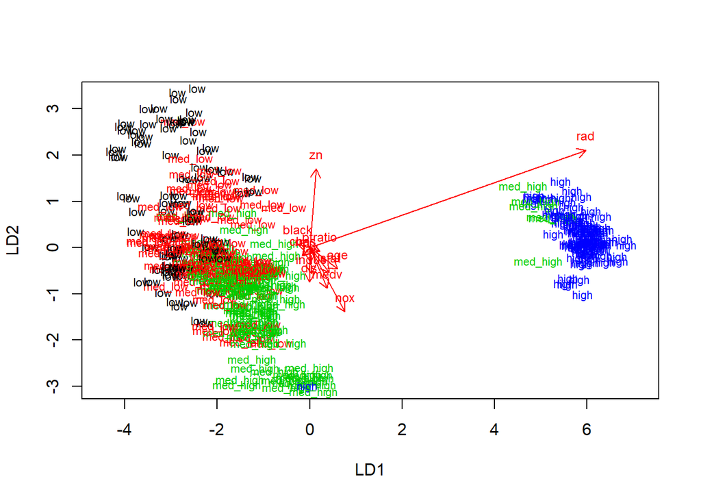

```r
# the function for lda biplot arrows
lda.arrows <- function(x, myscale = 1, arrow_heads = 0.1, color = "red", tex = 0.75, choices = c(1,2)){
  heads <- coef(x)
  arrows(x0 = 0, y0 = 0,
         x1 = myscale * heads[,choices[1]],
         y1 = myscale * heads[,choices[2]], col=color, length = arrow_heads)
  text(myscale * heads[,choices], labels = row.names(heads),
       cex = tex, col=color, pos=3)
}

# target classes as numeric
classes <- as.numeric(train$crime)

# plotting the lda results
plot(lda.fit, dimen = 2, col = classes, pch = classes)
lda.arrows(lda.fit, myscale = 2)
```

## Task 6: Predicting with the model

**Save the crime categories from the test set and then remove the categorical crime variable from the test dataset.**

```r
# saving crime categories
correct_classes <- test$crime

# removing the variable from test data
test <- dplyr::select(test, -crime)
```

**Then predict the classes with the LDA model on the test data. Cross tabulate the results with the crime categories from the test set. Comment on the results.**

```r
# predicting the classes with the model
lda.pred <- predict(lda.fit, newdata = test)

table(correct = correct_classes, predicted = lda.pred$class) %>%
  kable(caption = "<b>Table 5</b> Correct and predicted crime classes cross-tabulated") %>%
  kable_styling(bootstrap_options = "striped", "hover") %>%
  add_header_above(c("Correct crime class", "Predicted crime class" = 4))
```

**Table 5** Correct and predicted crime classes cross-tabulated

| Correct crime class | Predicted crime class low | Predicted crime class med_low | Predicted crime class med_high | Predicted crime class high |
| --- | --- | --- | --- | --- |
| low | 15 | 10 | 3 | 0 |
| med_low | 3 | 17 | 7 | 0 |
| med_high | 1 | 5 | 18 | 0 |
| high | 0 | 0 | 0 | 23 |

```r
# confusion matrix
confusionMatrix(lda.pred$class, correct_classes)
```

```
## Confusion Matrix and Statistics
##
##           Reference
## Prediction low med_low med_high high
##   low       15       3        1    0
##   med_low   10      17        5    0
##   med_high   3       7       18    0
##   high       0       0        0   23
##
## Overall Statistics
##
##                Accuracy : 0.7157
##                  95% CI : (0.6178, 0.8006)
##     No Information Rate : 0.2745
##     P-Value [Acc > NIR] : < 2.2e-16
##
##                   Kappa : 0.6211
##
##  Mcnemar's Test P-Value : NA
##
## Statistics by Class:
##
##                      Class: low Class: med_low Class: med_high Class: high
## Sensitivity              0.5357         0.6296          0.7500      1.0000
## Specificity              0.9459         0.8000          0.8718      1.0000
## Pos Pred Value           0.7895         0.5313          0.6429      1.0000
## Neg Pred Value           0.8434         0.8571          0.9189      1.0000
## Prevalence               0.2745         0.2647          0.2353      0.2255
## Detection Rate           0.1471         0.1667          0.1765      0.2255
## Detection Prevalence     0.1863         0.3137          0.2745      0.2255
## Balanced Accuracy        0.7408         0.7148          0.8109      1.0000
```

Overall the prediction accuracy of the model is about 70 % (changes when the code is rerun, because the test data is sampled randomly every time), which is quite a high accuracy rate with 4 classes. It seems that the predictions are more accurate when the true high crime rate is high.

## Task 7: K-Means clustering

**Reload the Boston dataset and standardize the dataset.**

```r
# reloading data
data("Boston")
Bos <- scale(Boston)
Bos <- as.data.frame(Bos)
```

**Calculate the distances between the observations.**

```r
# euclidean distance matrix
dist_eu <- dist(Bos)

#manhattan distance matrix
dist_man <- dist(Bos, method = "manhattan")

# summaries
summary(dist_eu)
```

```
##    Min. 1st Qu.  Median    Mean 3rd Qu.    Max.
##  0.1343  3.4625  4.8241  4.9111  6.1863 14.3970
```

```r
summary(dist_man)
```

```
##    Min. 1st Qu.  Median    Mean 3rd Qu.    Max.
##  0.2662  8.4832 12.6090 13.5488 17.7568 48.8618
```

**Run k-means algorithm on the dataset. Investigate what is the optimal number of clusters and run the algorithm again. Visualize the clusters (for example with the pairs() or ggpairs() functions, where the clusters are separated with colors) and interpret the results.**

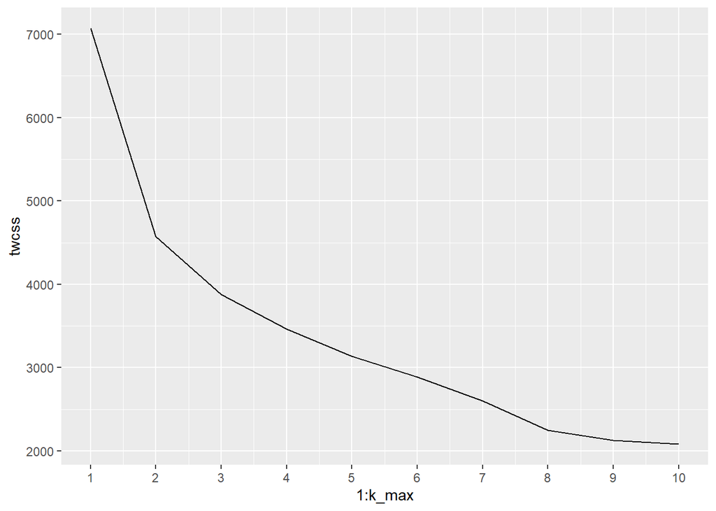

```r
# k-means clustering
km <-kmeans(Bos, centers = 4)

# determining k
set.seed(500)
k_max <- 10

# the total within sum of squares
twcss <- sapply(1:k_max, function(k){kmeans(Bos, k)$tot.withinss})
qplot(x = 1:k_max, y = twcss, geom = 'line') + scale_x_continuous(breaks = 1:10)
```

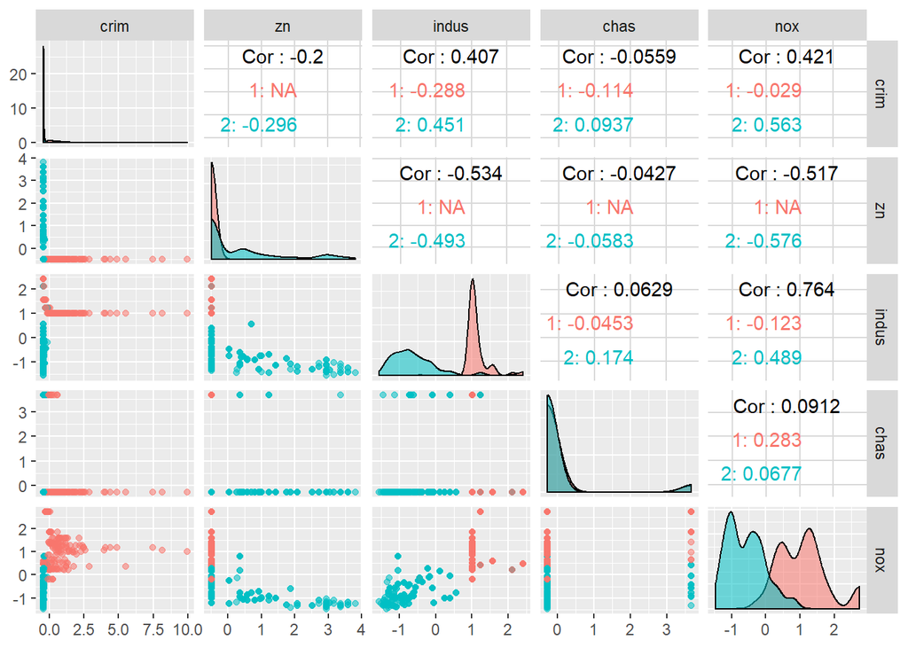

```r
# k-means clustering
km <-kmeans(Bos, centers = 2)

# comparing clusters
ggpairs(Bos[1:5], aes(col=factor(km$cluster), alpha = 0.3),
        lower = list(combo = wrap("facethist", bins = 20)))
```

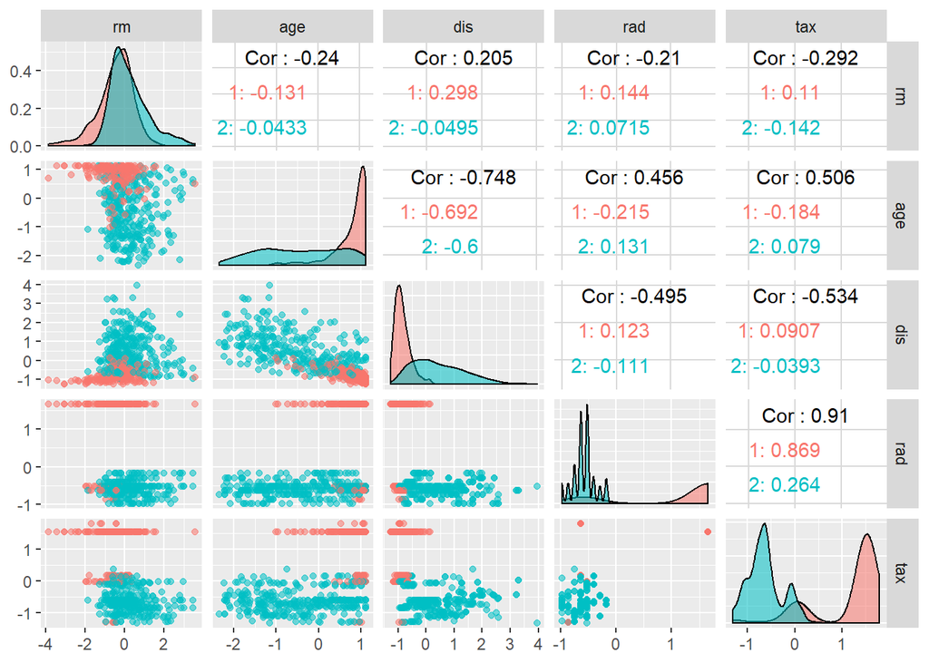

```r
ggpairs(Bos[6:10], aes(col=factor(km$cluster), alpha = 0.3),
        lower = list(combo = wrap("facethist", bins = 20)))
```

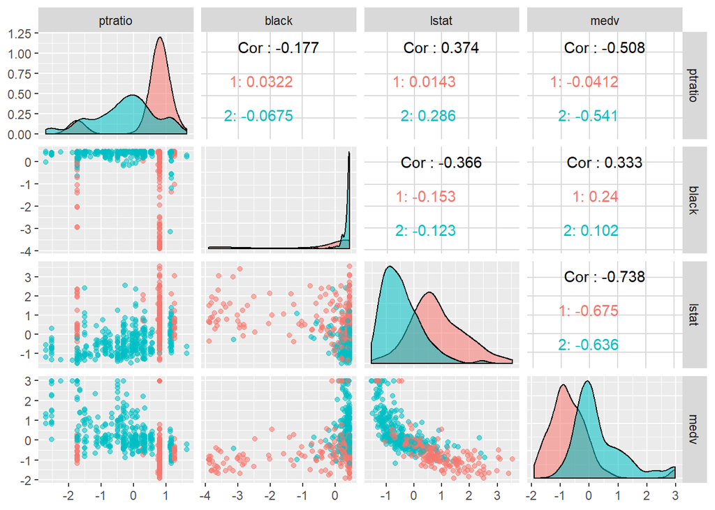

```r
ggpairs(Bos[11:14], aes(col=factor(km$cluster), alpha = 0.3),
        lower = list(combo = wrap("facethist", bins = 20)))
```

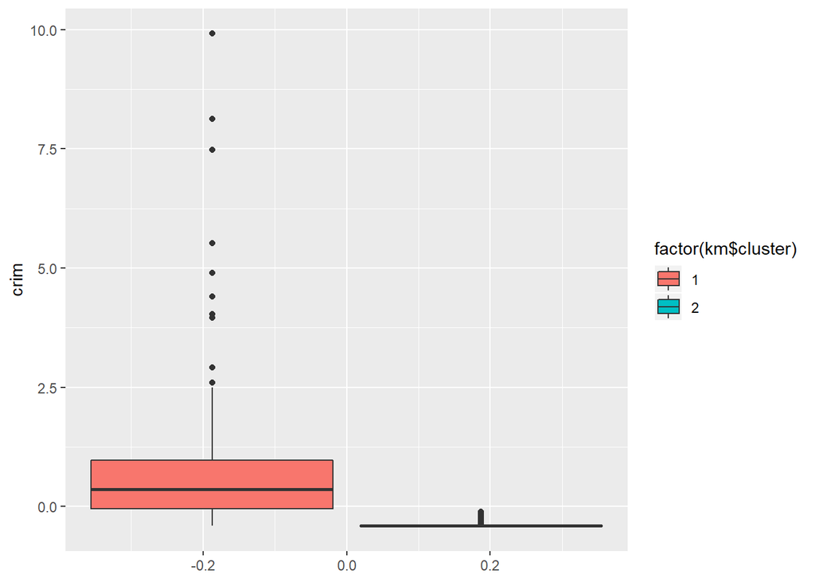

```r
ggplot(Bos, aes(group = km$cluster, y=crim, fill = factor(km$cluster))) + geom_boxplot()
```

It seems the most radical change (the “elbow”) in the total of within cluster sum of squares (WCSS) happens between one and two clusters. Although WCSS decreases with increase in clusters, the changes become increasingly subtle. Therefore, I chose a 2 cluster solution.

The clusters seem to differ in crime rate with cluster 2 with virtually no crime. The clusters also differ in proportion of non-retail business, nitrogen oxide concentration, proportion of old buildings, distance to employment centers, accessibilty of highways, property tax, and pupil-teacher ratio.